# TAP 02

Author

291928

```r
library(tidyverse)
library(dplyr)
library(ggplot2)
library(datawizard)
library(broom)
library(ggfortify)
library(patchwork)
library(kableExtra)
# load the data here

stats_tib <- here::here("/cloud/project/Data/tap_learning_statistics.csv") |>
  readr::read_csv()

# Changing community from a character variable to a factor variable

stats_tib$community <- as.factor(stats_tib$community)

# Releveling the community factor in this way 1- None 2- Online 3- In person

stats_tib$community <- forcats::fct_relevel(stats_tib$community , "None" , "Online" , "In person")
```

## Analysis plan

Regarding the provided hypothesis, it is assumed that the relationship between statistics anxiety (`stats_anxiety`) and students’ performance on their statistics exam (`stats_exam`) will be moderated by the community to which the student was assigned (community). Since a linear relationship is hypothesized, the general linear model should be utilized as the model. To test the moderating effect of the community (`community`) on the relationship between statistics anxiety (`stats_anxiety`) and students’ performance on statistics exam (`stats_exam`), the interaction effect between the predictor (statistics anxiety (`stats_anxiety`)) and moderator (community (`community`)) should be included in the model ($\text{statistics anxiety} \ \times \ \text{community}$). Also, for the second part of the hypothesis, there is a need to add contrasts to check whether the relationship between statistics anxiety (stats_anxiety) and students’ performance in statistics exam (`stats_exam`) is weaker among students who were assigned to a peer community compared to those not ($\text{contrast}_1$). Another contrast ($\text{contrast}_2$) should be included in the model to check whether the relationship between statistics anxiety (`stats_anxiety`) and students’ performance in statistics exam (`stats_exam`) is weaker among students who were assigned to the In-person community compared to those assigned to Online community. So to test the following hypothesis:

- H<sub>1</sub>: Performance on the statistics assignment (`stats_exam`) will be predicted by statistics anxiety (`stats_anxiety`), but this effect will be moderated by the community to which the student was assigned (`community`). Being in a learning community should reduce the relationship between statistics anxiety and statistics performance. Specifically, the relationship between statistics anxiety and statistics performance will be weaker in (1) those assigned to a peer community (online or in person) compared to those not; (2) those assigned to an In-person community compared to those assigned to an Online community.

The following model will be fitted:

$$performacne =$$

$$\hat{b_0} \ + \ \hat{b_1}statistics \ anxiety \ + \ \hat{b_2}community \ + \ \hat{b_3}(statistics \ anxiety \times \text{community})$$

Data for this analysis will be summarized and visualized as follows:

- Descriptive statistics (mean, standard deviation, inter-quartile range, skewness, kurtosis, and confidence intervals) of statistics anxiety (`stats_anxiety`) and performance on statistical module (`stats_exam`) will be provided to explore distributional properties and central tendencies related to data.
- Histograms of statistics anxiety (`stats_anxiety`) and students’ performance on the statistics module (`stats_exam`) to explore their distribution pattern and outliers.
- Box plots for statistics anxiety (`stats_anxiety`) and students’ performance on the statistics module (`stats_exam`) to explore possible outlier data.
- Descriptive statistics (mean, standard deviation, inter-quartile range, skewness, kurtosis, and confidence intervals) of statistics anxiety (`stats_anxiety`) and performance on statistical module (`stats_exam`) grouped by their community group will be presented to illustrate the overall status of central tendencies and distributional properties regarding students’ performance and students’ statistics anxiety in different community groups.
- Violin plots and mean of students’ performance on statistics exam (`stats_exam`) (y-axis) according to their community group (`community`) (x-axis) to show the distribution pattern of students’ performance regarding their community group.
- Scatter plot of statistics anxiety (`stats_anxiety`) (x-axis) against students’ performance (`stats_exam`) (y-axis) to verify the linearity assumption for the general linear model, which is the primary assumption that is made through the hypothesis.
- Correlation matrix for the relationship between statistics anxiety (`stats_anxiety`) and students’ performance on the statistics exam (`stats_exam`) grouped by their community group (`community`) to provide some initial information regarding the correlation of this relationship in different groups (None, Online, and In-person).
- Scatter plot of statistics anxiety (`stats_anxiety`) (x-axis) against students’ performance (`stats_exam`) (y-axis) grouped by their community group (`community`) to see the trend of the relationship according to students’ community group which gives initial information to find insight about whether the moderation effect is reasonable or not.

The general linear model will be fit. To check the generalizability of our results and to ensure that the utilized model is proper, assumptions of a generalized linear model should be checked as follows:

- **Linearity:** Since we are fitting a general linear model, it is the most important assumption. The relationship between predictor variable (statistics anxiety (`stats_anxiety`)) and outcome variables (students’ performance on the statistics exam (`stats_exam`)) should be linear. This assumption will be evaluated using Scatter plots of statistics anxiety (`stats_anxiety`) (x-axis) against students’ performance on the statistics module (`stats_exam`) (y-axis). Additionally, a scatter plot of fitted values (x-axis) against the residual values (y-axis) would be used as further evidence for linearity.
- **Homoscedasticity:** The variance of residuals should be consistent at different levels of the predictor variable. To check this assumption a scatter plot of fitted values (x-axis) against residuals (y-axis) will be utilized.
- **Independence:** The residual of one case should not be predicted based on the residual of another case. To check this assumption, a scatter plot of case number (x-axis) against standardized residual values (y-axis) would be used. Residuals should be randomly scattered over the length of the x-axis.
- **Normality:** Normality of model errors (residuals) should be assessed. Since the sample size is large enough, the normality of sampling distribution due to the central limit theorem (CLT) is assumed without further checking. Even due to the large sample size ($n = 1576$) normality of residuals is reasonable, a q-q plot of standardized residuals will be utilized for double-checking.

Contingency plans if any of the assumptions are not met:

- **Linearity:** If this assumption is violated, the general linear model will not fit anymore, and there is a need to utilize non-linear models.
- **Homoscedasticity:** If this assumption is violated, while estimates of betas would not impacted, standard error will become incorrect which makes p-value, t-value, and confidence intervals incorrect. In this scenario, robust models (Heteroscedasticity-consistent (HC4)) will be utilized which are not sensitive to the homoscedasticity assumption.
- **Independence:** If this assumption is violated, a multilevel model should be utilized.
- **Normality:** If this assumption is violated, robust models should be utilized. However, in our test, due to the large sample size, normality would not be an issue.

If the assumptions are met, then the fitted general linear model is appropriate and results are interpretable and generalizable. For interpretations, $\alpha = 0.05$ will be used as a significance criterion. However, if the assumptions are not met, a robust model of the general linear model will be used. Again, for this model, $\alpha =0.05$ will be used as a significance criterion. Also, to ensure the validity of the p-value, confidence intervals will be checked to ensure that they are not crossing zero in both scenarios (with and without meeting assumptions).

## Coding

### Summary statistics and data visualization

```r
# Descriptive statistics of statistics anxiety
# Descriptive statistics of students' performance

descriptive_variables <- stats_tib |>
  datawizard::describe_distribution(
    c(stats_anxiety , stats_exam),
    range = FALSE
  ) |>
  knitr::kable(digits = 3)

# Histogram of statistics anxiety

hist_stats_anxiety <- ggplot(stats_tib, aes(stats_anxiety)) +
  geom_histogram(binwidth = 1, fill = "#984ea3") +
  labs(x = "Statistics Anxiety" , y = "Density") +
  theme_bw()

# Histogram of students' performance

hist_stats_exam <- ggplot(stats_tib, aes(stats_exam)) +
  geom_histogram(binwidth = 1 , fill = "#984ea3") +
  labs(x = "Students' Performance" , y = "Density") +
  theme_bw()

# Box plot of statistics anxiety

box_stats_anxiety <- ggplot(stats_tib, aes(stats_anxiety)) +
  geom_boxplot(fill = "#ff7f00") +
  labs(x = "Statistics Anxiety" , y = "Density") +
  theme_bw()

# Box plot of students' performance

box_stats_exam <- ggplot(stats_tib, aes(stats_exam)) +
  geom_boxplot(fill = "#ff7f00") +
  labs(x = "Students' Performance" , y = "Density") +
  theme_bw()

# Descriptive statistics of statistics anxiety grouped by community group
# Descriptive statistics of students' performance grouped by community group

descriptive_variables_grouped <- stats_tib |>
  group_by(community) |>
  datawizard::describe_distribution(
    c(stats_anxiety , stats_exam),
    range = FALSE
  ) |>
  knitr::kable(digits = 3)

# Violin plot of statistics anxiety grouped by community group

violin_stats_anxiety <- ggplot(stats_tib, aes(community, stats_anxiety , color = community)) +
  geom_violin() +
  stat_summary(fun = mean , geom = "point") +
  stat_summary(fun.data = mean_cl_normal , geom = "errorbar") +
  labs(x = "Community" , y = "Statistics Anxiety") +
  theme_bw()

# Violin plot of students' performance grouped by community group

violin_stats_exam <- ggplot(stats_tib, aes(community, stats_exam , color = community)) +
  geom_violin() +
  stat_summary(fun = mean , geom = "point") +
  stat_summary(fun.data = mean_cl_normal , geom = "errorbar") +
  labs(x = "Community" , y = "Students' Performance") +
  theme_bw()

# Scatter plot of statistics anxiety against students' performance

linearity_scatter <- ggplot(stats_tib, aes(stats_anxiety , stats_exam)) +
  geom_point(alpha = 0.7) +
  geom_smooth(method = "lm") +
  labs(x = "Statistics Anxiety" , y = "Students' Performance") +
  theme_bw()

# Correlation matrix between statistics anxiety and students' performance
# grouped by community group

matrix_cor <- stats_tib |>
  group_by(community) |>
  summarise(correlation = cor(stats_anxiety , stats_exam)) |>
  knitr::kable(digits = 3)

# Scatter plot of the statistics anxirty against students' performance
# grouped by community group

community_cor_scatter <- ggplot(stats_tib, aes(stats_anxiety , stats_exam, color = community)) +
  geom_point(alpha = 0.7) +
  geom_smooth(method = "lm") +
  labs(x = "Statistics Anxiety" , y = "Students' Performance") +
  theme_bw()
```

### Statistic model

```r
# Defining contrasts prior to checking the impact of differtent levels of community
# on the relationship between statistics anxiety and students' performance

# Contrast_1 for the difference between None and students in any community group

community_vs_none <- c(-2/3 , 1/3 , 1/3)

# Contrast_2 for the difference between Online and In person community groups

inperson_vs_online <- c(0 , -1/2 , 1/2)

# Adjusting coded contrasts to community

stats_tib_contrast <- stats_tib
contrasts(stats_tib_contrast$community) <- cbind(community_vs_none , inperson_vs_online)

# Fitting the general linear model to see the moderation effect

normal_lm <- lm(stats_exam ~ stats_anxiety * community , data = stats_tib_contrast)

# Defining the result related to the main effect and interaction effect

main_inter_result <- car::Anova(normal_lm , type = 3) |>
  knitr::kable(digits = 3)

# Defining the effect size using partial omega square

effect_omega_result <- car::Anova(normal_lm , type = 3) |>
  effectsize::omega_squared(ci = 0.95) |>
  knitr::kable(digits = 3)

# Simple slopes

simple_slopes <- emmeans::joint_tests(normal_lm , "community") |>
  knitr::kable(digits = 3)

# make the results tidy and adding confidence intervals

estimate_result <- broom::tidy(normal_lm , conf.int = TRUE) |>
  knitr::kable(digits = 3)
```

### Model assumptions

```r
# Influential cases

outlier_cases <- ggplot2::autoplot(normal_lm, which = 4)

# Linearity and Homoscedasticity assumptions

linearity_homoscedasticity <- ggplot2::autoplot(normal_lm, which = 1)

# Independence (standardized residuals should be made first)

stats_tib_contrast$model_residuals <- normal_lm$residuals

stats_tib_contrast$standardized_model_residuals <- stats_tib_contrast$model_residuals / sd(stats_tib_contrast$model_residuals)


independece_scatter <- ggplot(stats_tib_contrast, aes(id , standardized_model_residuals)) +
  geom_point() +
  geom_smooth() +
  labs(x = "case id" , y = "Standardized Residuals")


# Normality

normality_model <- ggplot2::autoplot(normal_lm, which = 2)
```

### Robust model

```r
# A new robust model will be defined

stats_tib_contrast_rob <- stats_tib_contrast

normal_rob_lm <- robust::lmRob(stats_exam ~ stats_anxiety * community , data = stats_tib_contrast_rob)

# Defining the bias between models

normal_rob_lm_bias <- summary(normal_rob_lm)

bias_models <- normal_rob_lm_bias$biasTest |>
  knitr::kable(digits = 3)

# Defining the result related to the main effect and interaction effect

normal_rob_lm_result <- car::Anova(normal_rob_lm , type = 3) |>
  knitr::kable(digits = 2)


# Robust model fitted since the homoscedasticity assumption was not met

normal_rob <- parameters::model_parameters(normal_lm , ROBUST = TRUE , vcov = "HC4") |>
  knitr::kable(digits = 3)
```

## Report

### Summary statistics and data visualization

```r
descriptive_variables
```

Table 1

| Variable | Mean | SD | IQR | Skewness | Kurtosis | n | n_Missing |
| --- | --- | --- | --- | --- | --- | --- | --- |
| stats_anxiety | 39.944 | 6.909 | 9.00 | -0.081 | 0.218 | 1576 | 0 |
| stats_exam | 49.845 | 15.817 | 21.75 | -0.132 | -0.297 | 1576 | 0 |

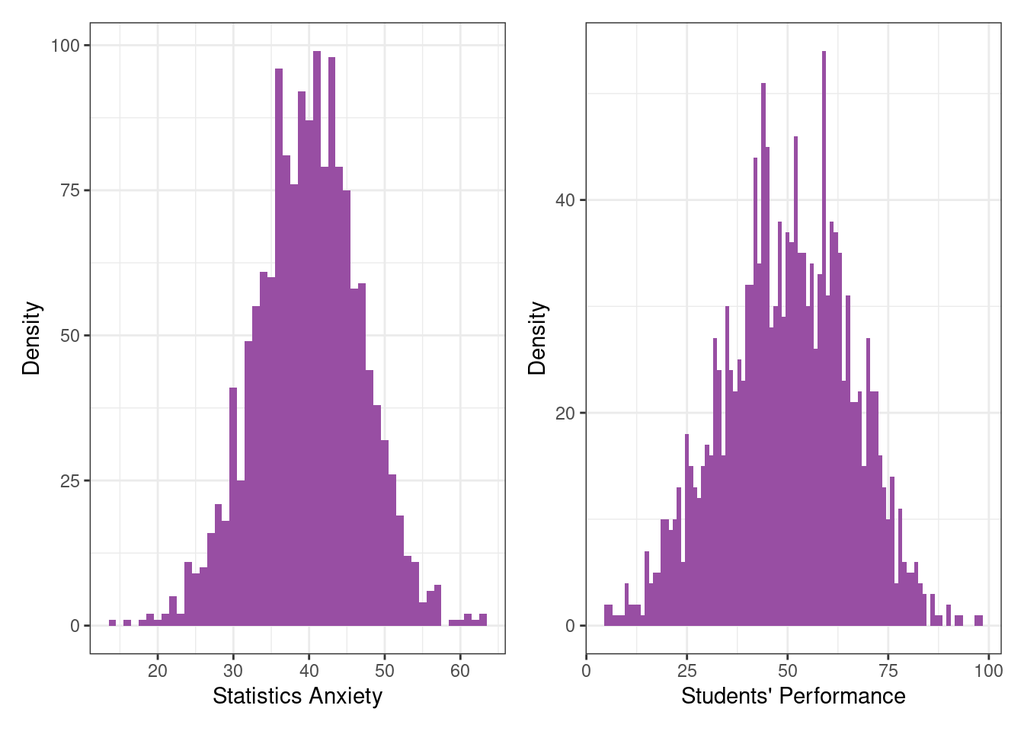

Figure 1

```r
hist_stats_anxiety + hist_stats_exam
```

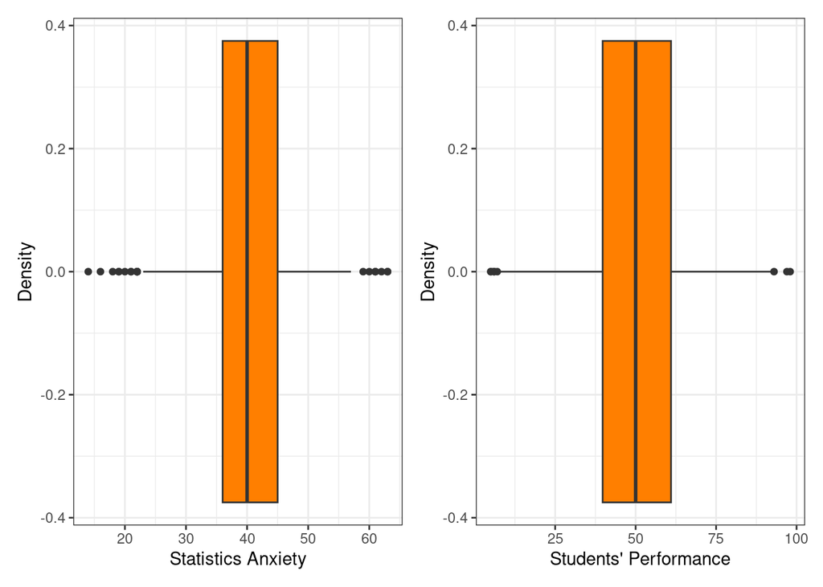

Figure 2

```r
box_stats_anxiety + box_stats_exam
```

illustrated box plots in Figure 2 show the inter-quartile range for statistics anxiety (`stats_anxiety`) and students’ performance on statistics exam (`stats_exam`). The mean for statistics anxiety is near 40 while the mean for students’ performance is near 50. The outliers are shown in these box plots with dots. As is presented the numbers of outlier cases compared to the large sample size (n = 1576) are pretty few. Consequently, it is reasonable to fit a model without much concern related to outlier cases. Also, the results of students’ performance and statistics anxiety are in the range of 0-100 and 0-65 respectively which means no obvious error in data entry can be seen for these two variables. Overall, there will be no outliers and case removal in this analysis.

```r
descriptive_variables_grouped
```

Table 2

| Variable | Mean | SD | IQR | Skewness | Kurtosis | n | n_Missing | .group |
| --- | --- | --- | --- | --- | --- | --- | --- | --- |
| stats_anxiety | 40.024 | 6.818 | 9.00 | -0.165 | 0.489 | 552 | 0 | community=None |
| stats_exam | 36.976 | 12.313 | 16.75 | -0.073 | -0.259 | 552 | 0 | community=None |
| stats_anxiety | 39.806 | 7.240 | 10.00 | -0.053 | 0.021 | 494 | 0 | community=Online |
| stats_exam | 49.879 | 11.473 | 17.00 | -0.111 | -0.101 | 494 | 0 | community=Online |
| stats_anxiety | 39.989 | 6.693 | 8.00 | -0.014 | 0.150 | 530 | 0 | community=In person |
| stats_exam | 63.217 | 10.599 | 15.00 | 0.127 | 0.000 | 530 | 0 | community=In person |

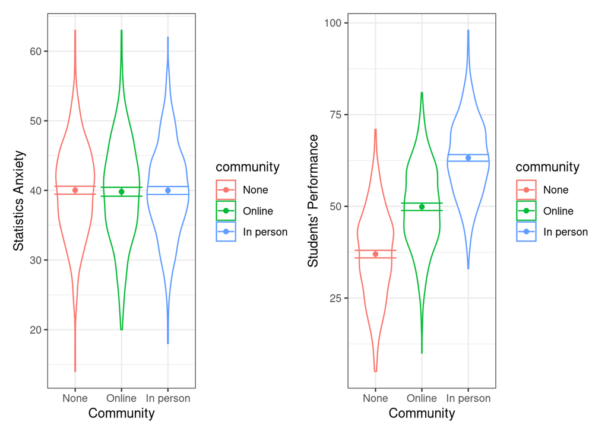

Figure 3

```r
violin_stats_anxiety + violin_stats_exam
```

The provided violin plots illustrated in Figure 3 show the distribution of statistics on anxiety score (`stats_anxiety`) and students’ performance score (`stats_exam`) grouped by the group to which they were allocated. As is demonstrated, the distribution of statistics anxiety (`stats_anxiety`) is pretty similar across the three groups. However, the following pattern is seen regarding the students’ performance across three groups: $\text{None} < \text{Online} < \text{In person}$ . This pattern aligns with Table 2 showing a sign of the moderating role of community (`community`).

```r
matrix_cor
```

Table 3

| community | correlation |
| --- | --- |
| None | -0.390 |
| Online | -0.318 |
| In person | -0.070 |

The provided Table 3 illustrates the relationship between statistics anxiety (`stats_anxiety`) and students’ performance (`stats_exam`) in three levels of community group (`community`) namely None, Online, and In-person. It is obvious that joining the online group decreased the aforementioned relationship. However, the difference between the In-person group and the other two groups is gigantic. Again, this information supports the idea of suggesting a community group (`community`) as a moderator.

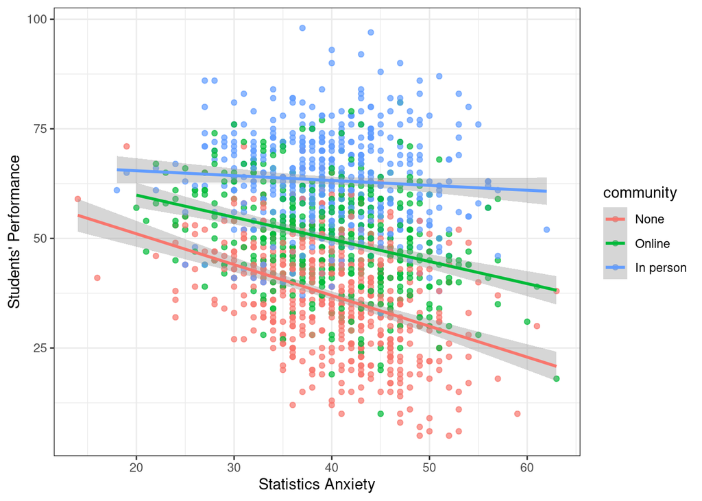

Figure 4

```r
community_cor_scatter
```

The scatter plot of the relationship between statistics anxiety (`stats_anxiety`) and students’ performance (`stats_exam`) grouped and divided by their community group (`community`) is presented in Figure 4 . While all lines show a negative slope, the slope for the In-person group is much smaller compared to the other groups and it is near to a flat line. This closeness to the flat line for the In-person group demonstrates that the In-person group played the role of a shield in the relationship between statistics anxiety (`stats_anxiety`) and students’ performance (`stats_exam`). Additionally, the negative slope for the students who were assigned to no group (None) was sharper compared to students assigned to the online group.

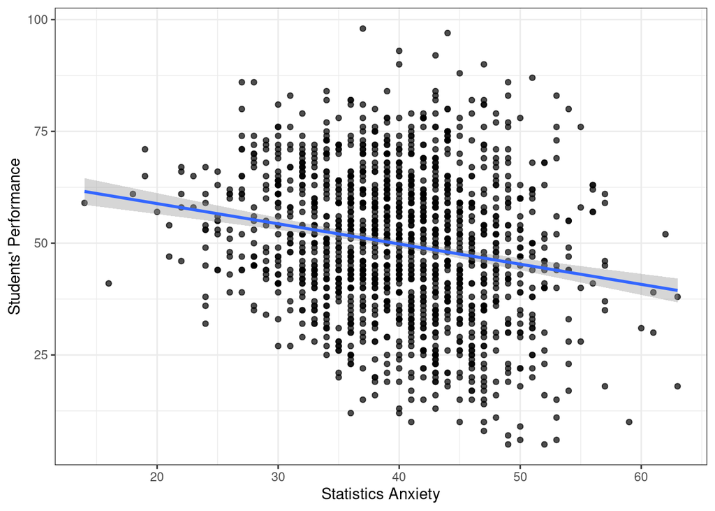

Figure 5

```r
linearity_scatter
```

Regarding the hypothesis, a general linear model will be fitted. However, linearity is the major assumption of the general linear model. Hence, the relationship between the predictor (statistical anxiety (`stats_anxiety`)) and outcome (students’ performance(`stats_exam`)) should be linear. According to Figure 5 statistical anxiety shows a linear relationship with students’ performance. Overall, this scatter plot shows a negative relationship between statistics anxiety (`stats_anxiety`) and students’ performance (`stats_exam`). Finally, this scatter plot shows the linearity, making it reasonable to fit a general linear model.

### Model assumptions

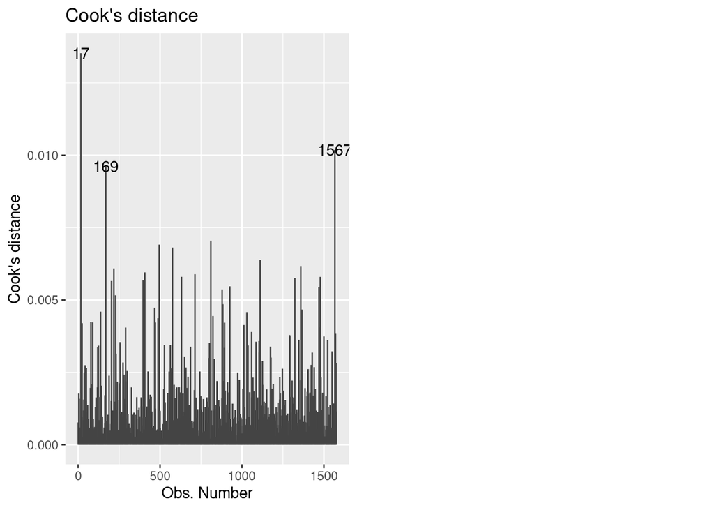

Figure 6

```r
outlier_cases
```

The provided Figure 6 provide information related to influential cases using Cook’s distance. Cases can be concerning when their Cook’s distance becomes more than $0.5$ or $1$. However, in this plot, no influential case can be seen. Additionally, due to the sample size and the fact that every thing assumed equal, there is no need for case removal. So, overall, there is no problem for continuing with fitted model.

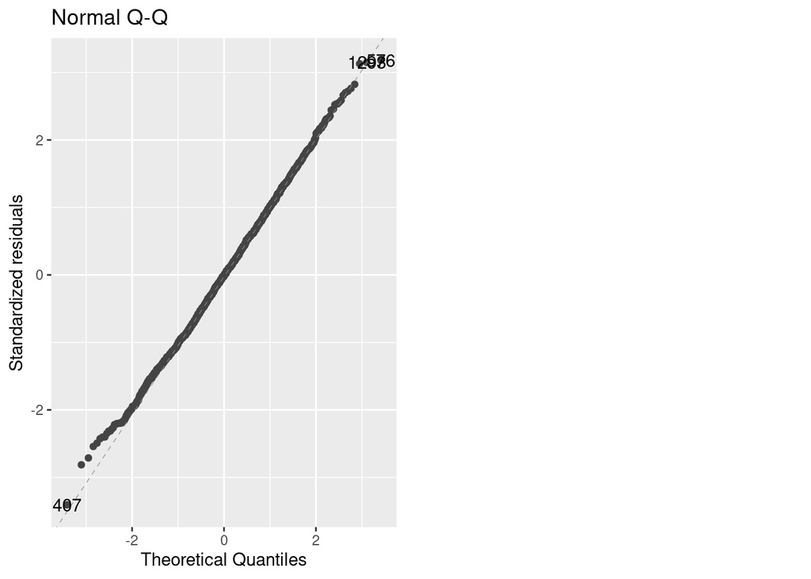

Figure 7

```r
normality_model
```

One of the assumptions for general linear model is the normality of errors (residuals) and normality of sampling distribution. Regarding normality for sampling distribution, since the sample size is large enough $(n = 1576)$, in accordance to the central limit theorem (CLT), the sampling distribution is normally distributed. Figure 7 a q-q plot for analyzing the normality of errors (residuals). Since the line is following the diagonal line, it is reasonable to mention that the residuals are normally distributed. So, the assumption of normality has been met.

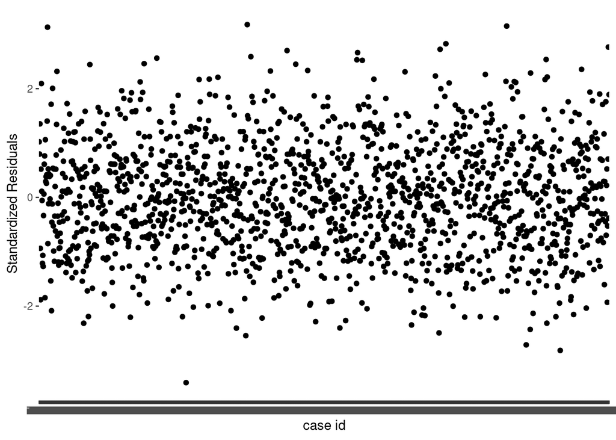

Figure 8

```r
independece_scatter
```

Independence of errors (residuals) is another assumption generalized linear model. The residual of one case should not be predicted by another case’s residual. Hence, by plotting residuals in the length of case ids (x-axis) no pattern should be seen and residuals should be scattered randomly. As is seen in Figure 8 , residuals are randomly scattered along the x-axis without following a specific pattern. Hence, the assumption of independence residuals is met.

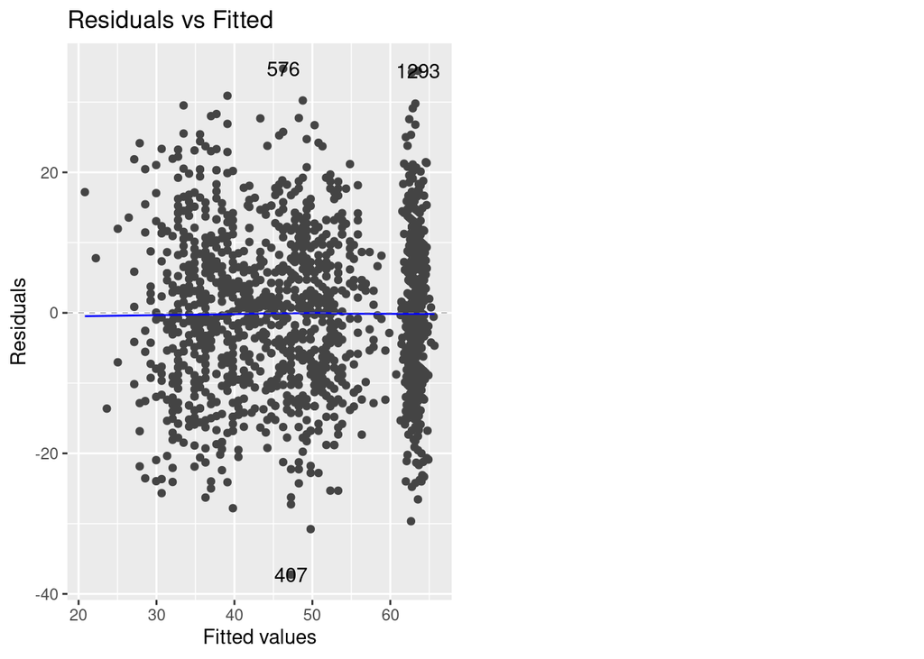

Figure 9

```r
linearity_homoscedasticity
```

### Statistical model

```r
normal_rob_lm_result
```

Table 4

|  | Df | Chisq | Pr(>Chisq) |
| --- | --- | --- | --- |
| (Intercept) | 1 | 1545.02 | 0.0 |
| stats_anxiety | 1 | 110.03 | 0.0 |
| community | 2 | 1.83 | 0.4 |
| stats_anxiety:community | 2 | 30.89 | 0.0 |

```r
normal_rob
```

Table 5

| Parameter | Coefficient | SE | CI | CI_low | CI_high | t | df_error | p |
| --- | --- | --- | --- | --- | --- | --- | --- | --- |
| (Intercept) | 67.589 | 1.548 | 0.95 | 64.552 | 70.626 | 43.654 | 1570 | 0.000 |
| stats_anxiety | -0.440 | 0.039 | 0.95 | -0.517 | -0.363 | -11.238 | 1570 | 0.000 |
| communitycommunity_vs_none | 3.688 | 3.341 | 0.95 | -2.865 | 10.240 | 1.104 | 1570 | 0.270 |
| communityinperson_vs_online | -2.293 | 3.726 | 0.95 | -9.602 | 5.016 | -0.615 | 1570 | 0.538 |
| stats_anxiety:communitycommunity_vs_none | 0.395 | 0.085 | 0.95 | 0.229 | 0.562 | 4.667 | 1570 | 0.000 |
| stats_anxiety:communityinperson_vs_online | 0.393 | 0.094 | 0.95 | 0.209 | 0.577 | 4.190 | 1570 | 0.000 |

The data in Table 5 is provided using a robust model by using the Heteroscedasticity-consistent ($HC4$) method to overcome the issue of heteroscedasticity. As is seen, being assigned to any learning group (online and in-person) significantly made the relationship between statistics anxiety (`stats_anxiety`) and students’ performance (`stats_exam`) weaker compared to being assigned in no group (none), $\hat{b}=0.395 \ [0.22,0.56], t = 4.66, p<0.001$. In the real world, it means that by increasing statistics anxiety (`stats_anxiety`) by one unit, the performance of students who were allocated to any learning group (online and in-person) would experience $0.39$ of a unit less decrease in their performance (`stats_exam`) compared to students who assigned to no group. Regarding the confidence intervals of this estimate, if this sample is one of the $95\%$ for which the confidence intervals contain the population value then the influence of being in a learning group compared to not being in one for the relationship between statistics anxiety and students’ performance can be as small as $\hat{b} = 0.22$ or as big as $\hat{b}=0.56$. Additionally, the mentioned confidence interval is not crossing zero which means the $p-value$ is truly significant and it is not caused by a large sample size. Also, in the real world, it shows a great impact. For instance, $10$ unit increase in statistics anxiety (stats_anxiety) would cause $3.9$ unit difference in the decrement which is seen in the learning group compared to being in no learning group. Since, according to Figure 2 the inter-quartile range is something between $37.5$ - $62.5$, $3.9$ less decrease in statistics exam seems significant.

Finally, same as previous main effect would be interpretable in the presence of interaction effects. Overall, regarding these results and conclusions, the second part of the hypothesis (Being in a learning community should reduce the relationship between statistics anxiety and statistics performance. Specifically, the relationship between statistics anxiety and statistics performance will be weaker in (1) those assigned to a peer community (online or in person) compared to those not; (2) those assigned to an In-person community compared to those assigned to an Online community) was approved too. Therefore, the null hypothesis ($H_0$) would be rejected and the suggested hypothesis is reasonable.

```r
bias_models
```

Table 6

|  | statistic | p-value |
| --- | --- | --- |
| M-estimate | 2.124 | 0.908 |
| LS-estimate | -18.999 | 1.000 |

According to the result shown in Table 6 the difference between the significancy of results provided with the robust method and normal method of general linear model is not significant. So, overall, the heteroscedasticity would not impact the final results and significancy tests.

```r
simple_slopes
```

Table 7

| model term | community | df1 | df2 | F.ratio | p.value |
| --- | --- | --- | --- | --- | --- |
| stats_anxiety | None | 1 | 1570 | 105.684 | 0.000 |
| stats_anxiety | Online | 1 | 1570 | 54.868 | 0.000 |
| stats_anxiety | In person | 1 | 1570 | 2.452 | 0.118 |

### Summary

To sum up, the model supported the provided hypothesis in both parts of the hypothesis. According to Table 4 , interaction effect is observed between students’ statistics anxiety and the learning group to which they are allocated. This significant interaction effect mentions the moderating role of learning group in the relationship between statistics anxiety and students’ performance. This result is in line with students’ performance mean according to different learnning group from Table 2 and the distribution pattern in the Figure 3 are assuring that learning group (community group) is playing a moderating role.

Regarding the second part of the hypothesis, according to Table 5 being in any learning group would reduce the relationship between statistics anxiety and students’ performance compared to not being in any group. Also, being in in-person would reduce the relationship significantly more compared to being in online learning group. In fact, being in the in-person group would be a protective factor for students to save themselves from being affected by their statistics anxiety in their statistics exam.

Overall, we fitted a general model to assess the moderating effect of learning community on the relationship between students’ statistics anxiety and thier performance in the statistics exam. We found that this moderation effect is justifiable and also the way that this moderator is affecting this relationship found to be in line with our first hypothesis. Hence the null hypothesis ($H_0$) was rejected and our hypothesis ($H_1$) was approved.